# Bioestadística Fundamental

Departamento de Estadística, Sede Bogotá

## Contenido

### Parte I: Introducción y media fracción

- Motivación: el costo del factorial completo.
- La media fracción $2^{k-1}$.
- Generador y relación de definición.
- Ejemplo: screening en arroz con $2^{4-1}$.
- Estructura de alias y efectos confundidos.
- ANOVA e interpretación de resultados.

### Parte II: Cuarta fracción y caso general

- La cuarta fracción $2^{k-2}$.
- Ejemplo: screening en papa con $2^{5-2}$.
- Estructura de alias con dos generadores.
- El diseño factorial fraccionado general $2^{k-p}$.
- Elección de generadores y diseño base.

### Parte III: Resolución de los diseños

- Diseños de Resolución III.
- Diseños de Resolución IV y V.
- Comparación de costos e información.
- Resumen general y tabla comparativa.

### Taller en clase

- Cinco ejercicios agrícolas resueltos en grupo.
- Construcción de generadores y alias.
- Selección de resolución según el objetivo.

Diseños Factoriales Fraccionados de Dos Niveles

¿Qué hacer cuando hay demasiados factores agronómicos para evaluar y muy pocos recursos (tiempo, terreno, un solo ciclo de cultivo) para correr el factorial completo?

## Motivación: el costo del factorial completo

En estudios de **screening** agronómico es común querer evaluar simultáneamente muchos factores: tipo de riego, dosis de nitrógeno, densidad de siembra, variedad, fungicida, momento de fertilización, etc. Un diseño factorial completo $2^k$ requiere $2^k$ corridas.

$k=4$ factores  
**16 corridas**

$k=5$ factores  
**32 corridas**

$k=6$ factores  
**64 corridas**

En un cultivo de arroz o papa, cada “corrida” es una parcela completa que debe sembrarse, manejarse y cosecharse durante **todo un ciclo del cultivo**. Con 6 factores, 64 parcelas en un solo ciclo son, en la práctica, inviables.

## El problema del screening agronómico

Un ingeniero agrónomo del Tolima quiere evaluar en arroz, en un único ciclo de cultivo, cuatro prácticas: tipo de riego, dosis de nitrógeno, densidad de siembra y variedad. El factorial completo $2^4=16$ exige 16 parcelas grandes, con repeticiones para estimar el error, recursos hídricos y mano de obra simultánea que la finca no tiene disponibles en una sola temporada.

La pregunta natural: ¿es posible obtener información útil sobre los **cuatro** factores usando **menos** de 16 corridas?

Respuesta: sí, mediante un **diseño factorial fraccionado**, sacrificando parte de la información sobre interacciones de orden alto, que en screening suelen ser despreciables.

## Principio de escasez de efectos

Los diseños fraccionados se justifican gracias al **principio de escasez de efectos** (sparsity of effects principle):

En la mayoría de los sistemas, la respuesta está dominada por unos pocos efectos principales e interacciones de bajo orden (2 factores); las interacciones de 3 o más factores casi siempre son despreciables.

Si las interacciones de orden alto son despreciables, podemos “sacrificarlas” deliberadamente para reducir el número de corridas, sin perder información relevante sobre los efectos principales.

## La media fracción del diseño $2^k$

La **media fracción** de un diseño $2^k$ utiliza solamente $2^{k-1}$ corridas: la mitad de las combinaciones de tratamiento del factorial completo.

Media fracción $2^{k-1}$

Se selecciona la mitad de las $2^k$ combinaciones de signos definida por un **generador**: una columna de interacción de alto orden que se utiliza para dividir el diseño completo en dos mitades (fracciones).

Para $k=4$ con generador $D=ABC$ (equivalentemente $I=ABCD$), se eligen las 8 corridas donde la columna $ABCD$ vale $+1$ (o, simétricamente, las 8 donde vale $-1$).

## El generador y la relación de definición

Si se define $D=ABC$, multiplicando ambos lados por $D$ se obtiene $D^2=ABCD$, y como $D^2=I$ (columna de unos), resulta:

Relación de definición

$$I = ABCD$$

- $I$ se llama **relación de definición** del diseño fraccionado.
- Cualquier efecto multiplicado (módulo 2) por $ABCD$ produce su **alias**: el efecto con el que queda confundido.
- Ejemplo: $A \times ABCD = A^2BCD = BCD$, por lo tanto $A$ y $BCD$ son **alias** (se confunden entre sí).

## Cómo se construyen los alias

Para encontrar el alias de cualquier efecto, se multiplica dicho efecto por la relación de definición $I=ABCD$, usando la regla de que cualquier letra elevada al cuadrado se vuelve $I$:

| Efecto | Cálculo del alias | Alias |
| --- | --- | --- |
| $A$ | $A\cdot ABCD=A^2BCD$ | $BCD$ |
| $B$ | $B\cdot ABCD=AB^2CD$ | $ACD$ |
| $C$ | $C\cdot ABCD=ABC^2D$ | $ABD$ |
| $D$ | $D\cdot ABCD=ABCD^2$ | $ABC$ |
| $AB$ | $AB\cdot ABCD=A^2B^2CD$ | $CD$ |
| $AC$ | $AC\cdot ABCD=A^2BC^2D$ | $BD$ |
| $AD$ | $AD\cdot ABCD=A^2BCD^2$ | $BC$ |

Cada efecto principal queda confundido con una interacción de tres factores; cada interacción de dos factores queda confundida con otra interacción de dos factores.

## Ejemplo agrícola: screening en arroz ($k=4$)

Un agrónomo del Tolima desea evaluar cuatro prácticas en arroz en un solo ciclo de cultivo, usando solo 8 parcelas en lugar de 16:

| Factor | Nivel ($-$) | Nivel ($+$) |
| --- | --- | --- |
| $A$: Riego | Intermitente | Continuo |
| $B$: Fertilización N | 100 kg/ha | 160 kg/ha |
| $C$: Densidad de siembra | 120 kg semilla/ha | 180 kg semilla/ha |
| $D$: Variedad | Fedearroz 60 | Fedearroz 174 |

Respuesta: rendimiento de arroz paddy (ton/ha). Generador: $D=ABC$, es decir $I=ABCD$.

## Construcción de la fracción: diseño base

El **diseño base** es un factorial completo $2^3$ en los factores $A$, $B$, $C$. La columna de la cuarta variable $D$ se obtiene multiplicando $D=A\times B\times C$:

| Corrida | $A$ | $B$ | $C$ | $D=ABC$ | Tratamiento |
| --- | --- | --- | --- | --- | --- |
| 1 | $-$ | $-$ | $-$ | $-$ | (1) |
| 2 | $-$ | $-$ | $+$ | $+$ | cd |
| 3 | $-$ | $+$ | $-$ | $+$ | bd |
| 4 | $-$ | $+$ | $+$ | $-$ | bc |
| 5 | $+$ | $-$ | $-$ | $+$ | ad |
| 6 | $+$ | $-$ | $+$ | $-$ | ac |
| 7 | $+$ | $+$ | $-$ | $-$ | ab |
| 8 | $+$ | $+$ | $+$ | $+$ | abcd |

Esta es la fracción “principal” ($I=+ABCD$): exactamente 8 de las 16 combinaciones del factorial completo.

## Datos del ensayo en arroz

Rendimiento observado (ton/ha de arroz paddy) en las 8 parcelas de la media fracción:

| Tratamiento | $A$ | $B$ | $C$ | $D$ | Rendimiento (ton/ha) |
| --- | --- | --- | --- | --- | --- |
| (1) | $-$ | $-$ | $-$ | $-$ | 5.43 |
| cd | $-$ | $-$ | $+$ | $+$ | 5.88 |
| bd | $-$ | $+$ | $-$ | $+$ | 6.24 |
| bc | $-$ | $+$ | $+$ | $-$ | 5.59 |
| ad | $+$ | $-$ | $-$ | $+$ | 6.35 |
| ac | $+$ | $-$ | $+$ | $-$ | 5.80 |
| ab | $+$ | $+$ | $-$ | $-$ | 6.16 |
| abcd | $+$ | $+$ | $+$ | $+$ | 6.65 |

## Cálculo de efectos: contrastes

Cada efecto se calcula igual que en un factorial completo, pero con divisor $N/2=4$ (la mitad del número de corridas $N=8$):

Cálculo del efecto

$$\text{Efecto} = \frac{\sum (\text{signo de la columna}) \times y}{N/2} = \frac{\text{contraste}}{4}$$

Ejemplo para $A$: contraste $=-5.43+(-5.88)+(-6.24)+(-5.59)+6.35+5.80+6.16+6.65=1.82$, efecto $A=1.82/4=0.455$.

## Resultado: efectos estimados (confundidos)

Como cada efecto principal está confundido con una interacción de tres factores y cada interacción de dos factores con otra interacción de dos factores, lo que se calcula es realmente la **suma** de ambos alias:

| Efecto estimado | Alias | Valor | SC (1 gl) |
| --- | --- | --- | --- |
| $A+BCD$ | $BCD$ | 0.4550 | 0.4141 |
| $B+ACD$ | $ACD$ | 0.2950 | 0.1741 |
| $C+ABD$ | $ABD$ | $-0.0650$ | 0.0085 |
| $D+ABC$ | $ABC$ | 0.5350 | 0.5724 |
| $AB+CD$ | $CD$ | 0.0350 | 0.0025 |
| $AC+BD$ | $BD$ | 0.0350 | 0.0025 |
| $AD+BC$ | $BC$ | $-0.0150$ | 0.0005 |

8 corridas → 7 grados de libertad disponibles (todos usados, sin gl para error puro).

## Tabla ANOVA de la media fracción

Al no haber repeticiones, la tabla ANOVA se construye con la suma de cuadrados de cada uno de los 7 efectos confundidos. La suma de cuadrados total coincide con la suma de las 7 componentes:

| Fuente | SC | gl |
| --- | --- | --- |
| $A$ (+ $BCD$) | 0.4141 | 1 |
| $B$ (+ $ACD$) | 0.1741 | 1 |
| $C$ (+ $ABD$) | 0.0085 | 1 |
| $D$ (+ $ABC$) | 0.5724 | 1 |
| $AB$ (+ $CD$) | 0.0025 | 1 |
| $AC$ (+ $BD$) | 0.0025 | 1 |
| $AD$ (+ $BC$) | 0.0005 | 1 |
| **Total** | **1.1746** | **7** |

Sin réplicas no hay grados de libertad para estimar el error puro: la inferencia formal (valor-p) requiere repetir el diseño o usar gráfico de probabilidad normal de efectos.

## Gráfico de efectos: identificación visual

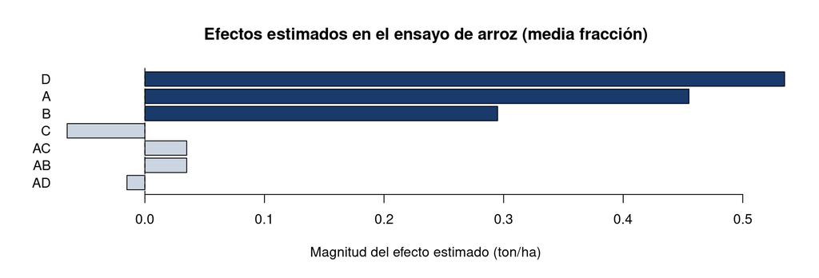

Los efectos $D$ (variedad), $A$ (riego) y $B$ (fertilización) destacan claramente sobre los demás, que se comportan como ruido aleatorio.

## Interpretación de resultados

Bajo el principio de escasez de efectos, se asume que las interacciones de tres factores ($BCD$, $ACD$, $ABD$, $ABC$) son despreciables. Entonces los efectos grandes observados se atribuyen a los efectos principales:

| Factor | Efecto | Interpretación |
| --- | --- | --- |
| $D$: Variedad | 0.535 | Fedearroz 174 rinde 0.535 ton/ha más que Fedearroz 60 |
| $A$: Riego | 0.455 | Riego continuo aumenta el rendimiento en 0.455 ton/ha |
| $B$: Fertilización N | 0.295 | 160 kg/ha de N aumenta el rendimiento en 0.295 ton/ha |

$C$ (densidad de siembra) y las interacciones de dos factores resultaron despreciables: en un futuro ensayo de confirmación podrían omitirse para simplificar el manejo agronómico.

## Errores comunes: media fracción

Advertencia: errores frecuentes

- Interpretar el efecto estimado de $A$ como si fuera “puro”, olvidando que en realidad es $A+BCD$.
- Elegir un generador de bajo orden (ej. $D=AB$ en vez de $D=ABC$) sin entender que esto degrada la resolución del diseño.
- Ejecutar la fracción complementaria sin necesidad cuando el principio de escasez de efectos ya resuelve la ambigüedad.
- Olvidar que sin réplicas no hay grados de libertad para el error puro: se requiere un gráfico de efectos o un diseño confirmatorio.

La cuarta fracción y el caso general $2^{k-p}$

Cuando hay aún más factores de screening, es posible reducir el número de corridas todavía más usando varios generadores simultáneos.

## La cuarta fracción del diseño $2^k$

La **cuarta fracción** $2^{k-2}$ utiliza solamente $2^{k-2}$ corridas: la cuarta parte del factorial completo. Requiere **dos generadores** independientes.

Cuarta fracción $2^{k-2}$

Se eligen dos generadores $P$ y $Q$ (columnas de interacción) que definen dos relaciones de definición $I=P$ e $I=Q$. El producto $P\times Q$ genera una tercera relación, llamada **relación de definición generalizada**:
$$I = P = Q = PQ$$

Cada efecto tendrá ahora **tres** alias (uno por cada elemento no trivial de la relación generalizada).

## Ejemplo agrícola: screening en papa ($k=5$)

Un productor de papa en Cundinamarca (zona de Subachoque) desea evaluar 5 prácticas agronómicas en un solo ciclo, usando apenas 8 parcelas en lugar de 32:

| Factor | Nivel ($-$) | Nivel ($+$) |
| --- | --- | --- |
| $A$: Riego | Secano | Suplementario |
| $B$: Fertilización N | 150 kg/ha | 250 kg/ha |
| $C$: Fertilización K | 100 kg/ha | 180 kg/ha |
| $D$: Densidad de siembra | 40 000 plantas/ha | 55 000 plantas/ha |
| $E$: Variedad | Parda Pastusa | Diacol Capiro |

Generadores elegidos: $D=AB$, $E=AC$, es decir $I=ABD=ACE$.

## Construcción de la cuarta fracción

El diseño base es nuevamente un factorial completo $2^3$ en $A$, $B$, $C$; las columnas de $D$ y $E$ se obtienen de los generadores:

| Corrida | $A$ | $B$ | $C$ | $D=AB$ | $E=AC$ | Trat. | Rend. (ton/ha) |
| --- | --- | --- | --- | --- | --- | --- | --- |
| 1 | $-$ | $-$ | $-$ | $+$ | $+$ | de | 22.12 |
| 2 | $-$ | $-$ | $+$ | $+$ | $-$ | cd | 19.54 |
| 3 | $-$ | $+$ | $-$ | $-$ | $+$ | be | 22.75 |
| 4 | $-$ | $+$ | $+$ | $-$ | $-$ | bc | 19.92 |
| 5 | $+$ | $-$ | $-$ | $-$ | $-$ | a | 21.06 |
| 6 | $+$ | $-$ | $+$ | $-$ | $+$ | ace | 22.98 |
| 7 | $+$ | $+$ | $-$ | $+$ | $-$ | abd | 22.84 |
| 8 | $+$ | $+$ | $+$ | $+$ | $+$ | abcde | 24.72 |

Respuesta: rendimiento de papa (ton/ha). 8 corridas en lugar de 32: una reducción del 75%.

## Relación de definición generalizada

Con generadores $D=AB$ y $E=AC$, la relación de definición generalizada se obtiene multiplicando: $I=ABD$, $I=ACE$, y el producto $ABD\times ACE=A^2BCDE=BCDE$.

Relación de definición generalizada

$$I = ABD = ACE = BCDE$$

Cada uno de los 7 efectos estimables tiene ahora **tres** alias, uno por cada palabra no trivial de la relación generalizada.

## Estructura de alias de la cuarta fracción

Multiplicando cada efecto principal por $I=ABD=ACE=BCDE$ se obtienen sus alias:

| Efecto | Alias 1 | Alias 2 | Alias 3 |
| --- | --- | --- | --- |
| $A$ | $BD$ | $CE$ | $ABCDE$ |
| $B$ | $AD$ | $ABCE$ | $CDE$ |
| $C$ | $ABCD$ | $AE$ | $BDE$ |
| $D$ | $AB$ | $ACDE$ | $BCE$ |
| $E$ | $ABDE$ | $AC$ | $BCD$ |
| $BC$ | $ACD$ | $ABE$ | $DE$ |
| $BE$ | $ADE$ | $ABC$ | $CD$ |

Importante: $A$ queda confundido con la interacción de dos factores $BD$ y con $CE$: este diseño es de **Resolución III**.

## Resultado: efectos calculados en el ensayo de papa

| Efecto | Confundido con | Valor estimado |
| --- | --- | --- |
| $A$ | $BD$, $CE$ | 1.8175 |
| $B$ | $AD$, $CDE$ | 1.1325 |
| $C$ | $AE$, $BDE$ | $-0.4025$ |
| $D$ | $AB$, $BCE$ | 0.6275 |
| $E$ | $AC$, $BCD$ | 2.3025 |
| $BC$ (+ $DE$) | $ACD$, $ABE$ | $-0.0725$ |
| $BE$ (+ $CD$) | $ADE$, $ABC$ | 0.0525 |

Note la curiosidad numérica: como $A$ y $BD$ son alias, su valor estimado de “$A$” es idéntico al de “$BD$” calculado por separado: ambos son la misma combinación lineal de los datos.

## Gráfico de efectos: ensayo de papa

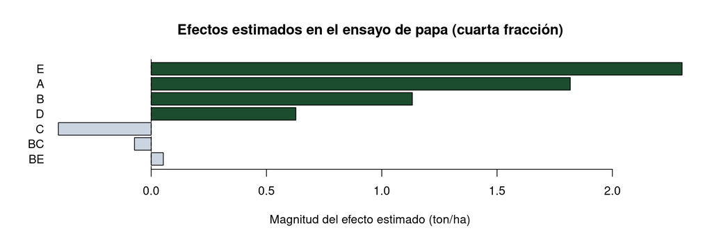

## Interpretación del ensayo de papa

Asumiendo que las interacciones de tres y más factores son despreciables (principio de escasez de efectos), los resultados sugieren:

| Factor | Efecto | Conclusión preliminar |
| --- | --- | --- |
| $E$: Variedad | 2.30 | Diacol Capiro supera a Parda Pastusa en 2.3 ton/ha |
| $A$: Riego | 1.82 | Riego suplementario aumenta el rendimiento en 1.82 ton/ha |
| $B$: Fertilización N | 1.13 | 250 kg/ha de N aumenta el rendimiento en 1.13 ton/ha |

## El diseño factorial fraccionado general $2^{k-p}$

En general, un diseño factorial fraccionado $2^{k-p}$ usa $2^{k-p}$ corridas: la $1/2^p$-ésima parte del factorial completo $2^k$, y requiere $p$ generadores independientes.

Diseño factorial fraccionado $2^{k-p}$

$$\text{Número de corridas} = 2^{k-p}
\qquad
\text{Número de generadores} = p$$

- El **diseño base** es un factorial completo $2^{k-p}$ en los primeros $k-p$ factores.
- Los $p$ factores restantes se asignan a columnas de interacción del diseño base (los generadores).
- La **relación de definición generalizada** contiene $2^p-1$ palabras (incluyendo los $p$ generadores y todos sus productos).

## Elección de generadores

La elección de los generadores determina la calidad del diseño fraccionado. Se busca que cada efecto principal quede confundido con interacciones del **mayor orden posible**.

**Buena elección**  
$D=ABC$ confunde efectos principales con interacciones de tres factores (escasas en la práctica)

**Mala elección**  
$D=AB$ confunde un efecto principal con una interacción de dos factores (frecuentemente importante)

El criterio formal para comparar generadores es la **resolución** del diseño, que se estudia en la siguiente sección.

Resolución de los diseños fraccionados

La resolución resume, en un solo número romano, cuán “limpia” es la información que un diseño fraccionado puede ofrecer.

## La resolución de un diseño

La **resolución** de un diseño fraccionado es igual a la **longitud de la palabra más corta** en la relación de definición generalizada (sin contar el símbolo $I$).

Resolución

Si la palabra más corta tiene $r$ letras, el diseño es de **Resolución $r$** (en números romanos). Por ejemplo, $I=ABCD$ tiene una sola palabra de longitud 4: Resolución IV.

A mayor resolución, menor confusión entre efectos de bajo orden: la información obtenida es “más limpia”.

## Diseños de Resolución III

Resolución III

Ningún efecto principal está confundido con otro efecto principal, pero los efectos principales **sí** están confundidos con interacciones de **dos** factores.

- Se usan para **screening puro**: identificar rápidamente cuáles de muchos factores son importantes, asumiendo que las interacciones son pequeñas.
- El ejemplo de papa ($I=ABD=ACE=BCDE$, palabra más corta de longitud 3) es de **Resolución III**.

Riesgo: si una interacción de dos factores es en realidad importante, el efecto principal correspondiente quedará sesgado sin que el investigador lo note.

## Ejemplo agrícola de Resolución III

En el ensayo de papa, $A$ (riego) está confundido con $CE$ (potasio $\times$ variedad) y con $BD$ (nitrógeno $\times$ densidad). Si en realidad existiera una interacción fuerte riego-variedad ($AE$), el agrónomo no podría distinguirla del efecto principal de fertilización K.

En la práctica agronómica, los diseños de Resolución III se usan como **primera etapa de screening**, seguida de un experimento confirmatorio con los factores que resultaron importantes.

## Diseños de Resolución IV

Resolución IV

Ningún efecto principal está confundido con interacciones de dos factores. Sin embargo, las interacciones de dos factores **sí** quedan confundidas entre sí.

- El ejemplo del arroz, con $I=ABCD$ (palabra de longitud 4), es de **Resolución IV**.
- Cada efecto principal está confundido únicamente con una interacción de **tres** factores, generalmente despreciable.
- Cada interacción de dos factores está confundida con otra interacción de dos factores: $AB$ con $CD$, $AC$ con $BD$, $AD$ con $BC$.

Los efectos principales se estiman limpiamente; solo las interacciones de dos factores quedan ambiguas entre sí.

## Diseños de Resolución V

Resolución V

Ningún efecto principal ni ninguna interacción de dos factores está confundida con otro efecto principal o interacción de dos factores. Las interacciones de dos factores quedan confundidas solo con interacciones de tres o más factores.

Se requiere una palabra mínima de longitud 5 en la relación de definición, por ejemplo $I=ABCDE$ para $k=5$, $p=1$ (media fracción de $2^5$, 16 corridas).

Resolución V exige más corridas que Resolución III o IV para el mismo número de factores, pero permite estimar limpiamente todas las interacciones de dos factores.

## Comparación: Resolución III vs. Resolución V para 5 factores

Para los mismos 5 factores agronómicos del ensayo de papa, se comparan dos posibles diseños fraccionados:

|  | Resolución III | Resolución V |
| --- | --- | --- |
| Diseño | $2^{5-2}_{III}$ | $2^{5-1}_{V}$ |
| Generador(es) | $D=AB$, $E=AC$ | $E=ABCD$ |
| Corridas | 8 | 16 |
| Efectos principales | Confundidos con interacciones de 2 factores | Libres de confusión |
| Interacciones de 2 factores | No estimables limpiamente | Libres de confusión entre ellas |

Duplicar el número de corridas (8 a 16) permite pasar de un screening “a ciegas” sobre interacciones a un diseño donde todas las interacciones de dos factores se estiman sin ambigüedad.

## Costo vs. información: la decisión práctica

La elección entre resoluciones es, en esencia, una decisión de **costo-beneficio** agronómico:

Pocas corridas, baja resolución

Ideal cuando hay **muchos** factores candidatos (8 o más) y el objetivo es descartar rápidamente los irrelevantes.

Más corridas, alta resolución

Apropiado cuando ya se redujo la lista a pocos factores (4 a 6) y se sospecha que las interacciones son importantes.

En la práctica agronómica colombiana, suele usarse una estrategia secuencial: Resolución III para el primer ciclo de screening, seguida de un diseño de mayor resolución (o el factorial completo) en el ciclo siguiente con los factores sobrevivientes.

## Resumen: tabla comparativa de fracciones

| Fracción | Notación | Generadores | Corridas ($k=5$) | Resolución típica | Qué se estima limpiamente |
| --- | --- | --- | --- | --- | --- |
| Completo | $2^5$ | Ninguno | 32 | $\infty$ | Todos los efectos |
| Media fracción | $2^{5-1}$ | 1 | 16 | V | Principales e interacciones de 2 factores |
| Cuarta fracción | $2^{5-2}$ | 2 | 8 | III | Solo efectos principales (con riesgo de confusión) |

## Resumen: qué efectos se pueden estimar

| Resolución | Efectos principales | Interacciones de 2 factores |
| --- | --- | --- |
| III | Confundidos con interacciones de 2 factores | No estimables limpiamente |
| IV | Libres de confusión | Confundidas entre sí |
| V | Libres de confusión | Libres de confusión |

Esta tabla resume el criterio práctico para elegir el diseño fraccionado adecuado al objetivo del experimento agronómico.

## Errores comunes: resolución y diseños fraccionados

Advertencia: errores frecuentes

- Usar un diseño de Resolución III y luego interpretar las interacciones de dos factores como si estuvieran limpiamente estimadas.
- Elegir generadores de bajo orden (ej. $D=AB$) sin verificar la resolución resultante.
- Olvidar reportar la relación de definición generalizada al comunicar los resultados del experimento.
- Confundir “menos corridas” con “menos información útil”: con buena elección de generadores, el screening de Resolución III sigue siendo muy valioso para descartar factores irrelevantes.

## Taller en Clase

## Instrucciones

Trabaje en grupos de 2 a 3 estudiantes. Para cada ejercicio: identifique el diseño fraccionado adecuado ($2^{k-p}$), proponga el o los generadores, escriba la relación de definición (generalizada si aplica), determine la resolución del diseño y liste la estructura de alias de los efectos principales.

Tiempo sugerido: 25 minutos. Cada grupo presentará la solución de un ejercicio asignado.

## Ejercicio 1

Un caficultor del Huila desea evaluar en un solo ciclo de cosecha 4 prácticas: sombrío (con/sin), tipo de poda, fertilización foliar (sí/no) y densidad de siembra. Decide usar una media fracción $2^{4-1}$ con generador $D=ABC$.

1. Escriba la relación de definición y la estructura completa de alias.
2. Determine la resolución del diseño.
3. Construya la tabla de signos de las 8 corridas y asigne los nombres de tratamiento (notación con minúsculas).

## Ejercicio 2

Para el ensayo de café del Ejercicio 1, se obtuvieron los siguientes rendimientos (sacos/ha), en el mismo orden de corridas que la tabla de signos calculada: 28.4, 30.1, 29.8, 33.2, 31.5, 30.9, 32.6, 35.1.

1. Calcule los 7 efectos confundidos usando el método de contrastes.
2. Calcule la suma de cuadrados de cada efecto.
3. Identifique cuáles factores parecen tener un efecto importante sobre el rendimiento.

## Ejercicio 3

Una empresa de flores de exportación en Cundinamarca quiere evaluar 6 factores de cultivo de rosas (temperatura de invernadero, humedad relativa, tipo de sustrato, fertirriego, fotoperiodo artificial y variedad) usando un diseño de Resolución III con el menor número de corridas posible.

1. ¿Cuántas corridas mínimas se necesitan para un diseño $2^{6-p}$ de Resolución III?
2. Proponga generadores adecuados y escriba la relación de definición generalizada.
3. Justifique por qué este diseño es apropiado para una primera etapa de screening con tantos factores.

## Ejercicio 4

Un ingenio en el Valle del Cauca evalúa el efecto de 5 factores sobre el rendimiento de caña de azúcar (toneladas de caña por hectárea): variedad, dosis de nitrógeno, riego, control de malezas y densidad de siembra. Se compara un diseño $2^{5-2}_{III}$ (8 corridas) contra un diseño $2^{5-1}_{V}$ (16 corridas).

1. Proponga generadores válidos para cada diseño y verifique su resolución.
2. Explique qué información adicional se gana al duplicar las corridas (de 8 a 16).
3. Si el ingenio sospecha una interacción fuerte entre riego y dosis de nitrógeno, ¿cuál diseño recomendaría y por qué?

## Ejercicio 5

Un investigador de la Universidad Nacional, sede Palmira, diseña un experimento de screening con 4 factores en maíz (variedad, densidad, fertilización N y control fitosanitario) y elige, por error, el generador $D=AB$ para una media fracción $2^{4-1}$.

1. Escriba la relación de definición y la estructura de alias resultante.
2. Determine la resolución de este diseño y compárela con la del generador $D=ABC$ usado en el ejemplo del arroz.
3. Explique por qué $D=AB$ es una mala elección de generador y qué riesgo práctico implica para la interpretación agronómica de los resultados.